Reviews

Neuroprotective Properties of Vitamin C:

A Scoping Review of Pre-Clinical and Clinical Studies

Lauren Kangisser,<sup>1,</sup>*Elinor Tan,<sup>1,</sup>*Rinaldo Bellomo,<sup>1,2</sup>Adam M. Deane,<sup>1,2</sup>and Mark P. Plummer<sup>1,2</sup>

Abstract

There is a need for novel neuroprotective therapies. We aimed to review the evidence for exogenous vitamin C as a

neuroprotective agent. MEDLINE, Embase, and Cochrane library databases were searched from inception to May 2020.

Pre-clinical and clinical reports evaluating vitamin C for acute neurological injury were included. Twenty-two pre-clinical

and 11 clinical studies were eligible for inclusion. Pre-clinical studies included models of traumatic and hypoxic brain

injury, subarachnoid and intracerebral hemorrhage, and ischemic stroke. The median [IQR] maximum daily dose of

vitamin C in animal studies was 120 [50–500] mg/kg. Twenty-one animal studies reported improvements in biomarkers,

functional outcome, or both. Clinical studies included single reports in neonatal hypoxic encephalopathy, traumatic brain

injury, and subarachnoid hemorrhage and eight studies in ischemic stroke. The median maximum daily dose of vitamin C

was 750 [500–1000] mg, or *10 mg/kg for an average-size adult male. Apart from one case series of intracisternal

vitamin C administration in subarachnoid hemorrhage, clinical studies reported no patient-centered beneﬁt. Although pre-

clinical trials suggest that exogenous vitamin C improves biomarkers of neuroprotection, functional outcome, and mor-

tality, these results have not translated to humans. However, clinical trials used approximately one tenth of the vitamin C

dose of animal studies.

Keywords: ascorbic acid; neuroprotection; stroke; subarachnoid hemorrhage; traumatic brain injury; vitamin C

V<sup>Introduction</sup>

itamin C, or ascorbic acid, is an essential micronutrient with

a normal plasma concentration of 30–80 lmol/L.<sup>1</sup>Ap-

proximately 90% of vitamin C is present in the plasma as

ascorbic acid and 10% as dehydroascorbic acid (DHA), the re-

>60 enzyme reactions that control a broad range of vital bio-

chemical reactions.<sup>1</sup>Importantly, vitamin C is the primary cir-

culatory antioxidant depleted during oxidative stress and is the

only antioxidant capable of preventing lipoprotein peroxida-

tion.<sup>3</sup>Brain tissue is highly susceptible to oxidative lipid damage

because of its large oxygen demand and high content of poly-

unsaturated fatty acid.<sup>1</sup>In health, vitamin C concentrations are

80 times greater in brain cells and 4 times greater in cerebro-

spinal ﬂuid compared to plasma, driven by active transport.<sup>4</sup>This

active concentration of vitamin C in the central nervous system is

thought to be an evolutionary adaptation to protect against

neuronal oxidative stress.<sup>5</sup>

Humans do not synthesize vitamin C, and, in health, mainte-

nance of total body stores is dependent on dietary intake.<sup>6</sup>Rapid

and substantial vitamin C deﬁciency is reported from blood sam-

ples obtained after a multitude of neurological insults, including

traumatic brain injury, ischemic stroke, intracerebral hemorrhage,

and subarachnoid hemorrhage.<sup>7–10</sup>Further, the nadir in vitamin C

concentration correlates with worse functional outcome.<sup>7,8</sup>This fall

in antioxidant capacity parallels an overwhelming increase in free

radicals and reactive oxygen species, which is thought to be central

to the pathogenesis of these neurological insults.<sup>11</sup>

Systematic reviews have focused on the possible efﬁcacy of

supplementing vitamin C during excessive oxidative stress in

sepsis, cancer, and post-cardiac arrest.<sup>12–14</sup>However, there has

been no comprehensive review of the possible neuroprotective

properties of vitamin C. Accordingly, we aimed to systematically

review all currently available reports of the therapeutic properties

of exogenous vitamin C after acute neurological insults.

Methods

Study design

We conducted a systematically structured scoping review using

the guidelines from the Cochrane Collaboration and Centre for

Reviews and Dissemination and reported the results according to

1Department of Intensive Care, Royal Melbourne Hospital, Parkville, Victoria, Australia.

2Centre for Integrated Critical Care, Department of Medicine and Radiology, University of Melbourne, Melbourne, Victoria, Australia.

*These authors contributed equally.

JOURNAL OF NEUROTRAUMA 38:2194–2205 (August 15, 2021)

ª Mary Ann Liebert, Inc.

DOI: 10.1089/neu.2020.7443

2194

the PRISMA (Preferred Reporting Items for Systematic Reviews

and Meta-Analyses) guideline and its extension for scoping

reviews.<sup>15</sup>

Inclusion and exclusion criteria

Eligible studies met the following criteria: 1) randomized con-

trolled trials, non-randomized controlled trials (case control or

controlled cohort), observational studies, and case series; 2) study

population was divided into pre-clinical animal models and clinical

studies of adult and pediatric populations; 3) exposure to traumatic

brain injury, hypoxic brain injury, ischemic stroke, intracerebral

hemorrhage, or subarachnoid hemorrhage; and 4) outcomes of

neuroprotection were reported after the administration of exoge-

nous vitamin C by any route. Studies that reported the effect of

vitamin C in combination with other interventions were included.

Studies reporting only in vitro data were excluded. We included

only studies reported in English. No data or publication status re-

strictions were imposed.

Deﬁnition of neuroprotection

Neuroprotection in this systematic review was deﬁned as any

outcome measure that was proposed by the original authors to be

favorable to brain function or neurological performance. This in-

cluded studies reporting post-mortem pathology, neuroimaging,

plasma and cerebrospinal ﬂuid biomarkers, vasospasm, blood–

brain barrier integrity, functional outcome scores (both animal and

human), and mortality.

Data sources and search strategy

A librarian and two reviewers (L.K. and E.T.) searched MED-

LINE (Ovid), EMBASE (Ovid), and Cochrane Library databases

from their inception to May 2020. Searches included synonyms and

combinations of the following terms: subarachnoid hemorrhage,

stroke, traumatic brain injury, and vitamin C. Terms were truncated

in order to capture variable terminology. The full search strategies

are provided in Supplementary Materials Additional File S1. We

applied no language restrictions during the searches. We also re-

viewed reference lists of retrieved articles to identify studies not

captured in the primary search.

Study selection and data extraction

Two reviewers independently screened titles and abstracts of all

identiﬁed studies. Relevant studies were independently evaluated

in full text for eligibility. Disagreements were resolved by con-

sensus or by consultation with a third reviewer (M.P.). Two re-

viewers independently extracted data from included studies using a

standardized data collection form. Extracted information included

study characteristics (author, publication year, design, and sample

size), participant characteristics (species [for pre-clinical studies]),

diagnosis of injury model, dose and route of vitamin C, other in-

terventions in each arm, and metric of neuroprotection. The sup-

plementary ﬁles of all included studies were also examined for the

purposes of data extraction. A meta-analysis of randomized,

placebo-controlled, clinical trials of vitamin C monotherapy was

planned if including at least three studies.

Bias and quality assessment

The methodological quality of the pre-clinical studies was as-

sessed using the Systematic Review Center for Laboratory animal

Experimentation (SYRCLE) checklist.<sup>16</sup>Risk of bias in human

randomized controlled trials was assessed using the Cochrane risk-

of-bias tool.<sup>17</sup>Risk of bias in human non-randomized trials was

assessed using the ‘‘Risk Of Bias In Non-randomized Studies – of

Interventions’’ (ROBINS-I) tool.<sup>18</sup>

Results

Our search retrieved 1520 citations with 251 full-text articles

assessed for eligibility. After full text extraction, 33 studies (22 pre-

clinical and 11 clinical) met the eligibility criteria (Fig. 1). Char-

acteristics of the included studies are summarized in Tables 1 and 2.

In studies reporting multiple interventions, only the vitamin C

(or vitamin C combination therapy) arm is presented.

Pre-clinical studies

In21ofthe22trials,vitaminCtherapyimprovedsecondarymarkers

of brain injury, functional outcome, or both (Table 1). Animal studies

included models of hypoxic brain injury,<sup>19,20</sup>intracranial hemor-

rhage,<sup>21</sup>ischemic stroke,<sup>22–33</sup>subarachnoid hemorrhage,<sup>34–36</sup>and

traumatic brain injury.<sup>37–40</sup>Allofthe studies were shamintervention or

placebo-controlled trials. Dosing regimens are outlined in Table 1. The

median [interquartile range; IQR] daily dose in pre-clinical studies was

120 [50–500] mg/kg. Six studies administered vitamin C pre-

insult,<sup>19,20,23,25,26,28</sup>two at the time of the insult,<sup>27,35</sup>nine post-

insult,<sup>22,24,29–31,34,36,38,40</sup>and ﬁve pre- and post-insult.<sup>21,32,33,37,39</sup>The

summary of the risk of bias assessment is displayed in Figure 2.

Hypoxic brain injury

In neonatal rat models of global hypoxic brain injury, Miura and

colleagues demonstrated that intracisternal vitamin C (up to

5 mg/kg) and intraperitoneal vitamin C (750 mg/kg) decreased

neuronal cell death<sup>19,20</sup>(Table 1).

Intracranial hemorrhage.

In the only pre-clinical trial re-

porting no improvement with vitamin C, Peeling and colleagues

demonstrated no effect of oral vitamin C (up to 120 mg/kg) and E

supplementation on functional outcome, brain edema, or hematoma

size in a murine model of intracranial hemorrhage<sup>21</sup>(Table 1).

Ischemic stroke.

All twelve studies utilizing animal models of

ischemic stroke reported signiﬁcant neuroprotective properties of

vitamin C (or its analogues) when given as monotherapy,<sup>23,25,27,29–31</sup>

as part of a therapeutic cocktail,<sup>24</sup>or both<sup>22,26,28,32,33</sup>(Table 1). The

median [IQR] maximum daily dose was 150 [88–500] mg/kg.

Subarachnoid hemorrhage.

Three studies describe vitamin

C attenuating vasospasm post–subarachnoid hemorrhage at an in-

tracisternal

dose

of

1.2 mg/kg

and

intramuscular

dose

of

120 mg/kg/d<sup>34–36</sup>(Table 1).

Traumatic brain injury.

There have been four studies of vi-

tamin C administration using rat models of traumatic brain injury,

all of which demonstrated improvements in functional outcome

(Table 1).<sup>37–40</sup>Interpretation of results from the study by Ishaq and

colleagues is limited given that the route of vitamin C is not pre-

sented nor is any statistical analysis of survival<sup>37</sup>(Table 1). The

Clinical studies

In 5 of 11 clinical studies,<sup>41–45</sup>vitamin C improved secondary

markers of brain injury, including perilesional edema in traumatic

brain injury, and markers of oxidative stress after ischemic stroke.

However, these effects did not translate to an improvement in any

patient-centered outcomes. Clinical studies included one random-

ized

controlled

trial

in

neonates

after

hypoxic

ischemic

2195

encephalopathy,<sup>46</sup>one case series in adult patients after subarach-

noid hemorrhage,<sup>47</sup>one randomized controlled trial in traumatic

brain injury,<sup>45</sup>and eight studies in ischemic stroke; which included

one observational study, one case-control study, and six randomized

controlled trials.<sup>41–44,48–51</sup>Vitamin C as ascorbic acid was the only

analogue studied, both as monotherapy<sup>45,49–51</sup>or as part of a com-

bination treatment arm.<sup>41–44,46–48,50</sup>Oral doses ranged from 200<sup>41</sup>to

1000 mg/d,<sup>50</sup>and intravenous doses ranged from 500 mg/d<sup>45,49</sup>to

10 g/d.<sup>45</sup>One case series in patients with subarachnoid hemorrhage

infused vitamin C, in combination with the thrombolytic urokinase,

directly into the subarachnoid space by an intracisternal catheter at a

dose of 120 mg/h (2.88 g/d) for 2–18 days.<sup>52</sup>The median [IQR]

maximum daily dose of vitamin C in adult trials was 750 [500–1000]

mg or *10mg/kg in an average-size adult male.

The clinical heterogeneity of these studies failed to meet the pre-

deﬁned threshold for meta-analysis. The summary of the risk of

bias for the eight randomized controlled trials and two non-

randomized trials are displayed in Figures 3 and 4, respectively.

The case series was not subjected to bias assessment.<sup>47</sup>

Neonatal hypoxic ischemic encephalopathy.

In a pro-

spective, double-blind, placebo-controlled trial of 60 neona-

tes with hypoxic ischemic encephalopathy, intravenous vitamin

C (100 mg/kg/d) in combination with ibuprofen had no effect

on inﬂammatory markers, hospital mortality, or functional

outcome.<sup>46</sup>

Ischemic stroke.

No human trials have demonstrated any

patient-centered beneﬁt from oral or intravenous vitamin C in the

management of ischemic stroke. Four randomized controlled trials

utilizing disparate regimens of vitamin C have demonstrated an

to improve neurological or functional outcome both in the acute

setting<sup>41,51</sup>and when administered for up to 1 year post-insult.<sup>48</sup>

Only one trial administered vitamin C parenterally (500 mg/d).<sup>49</sup>

The median maximum daily dose in trials of oral vitamin C was 500

(305–500) mg.

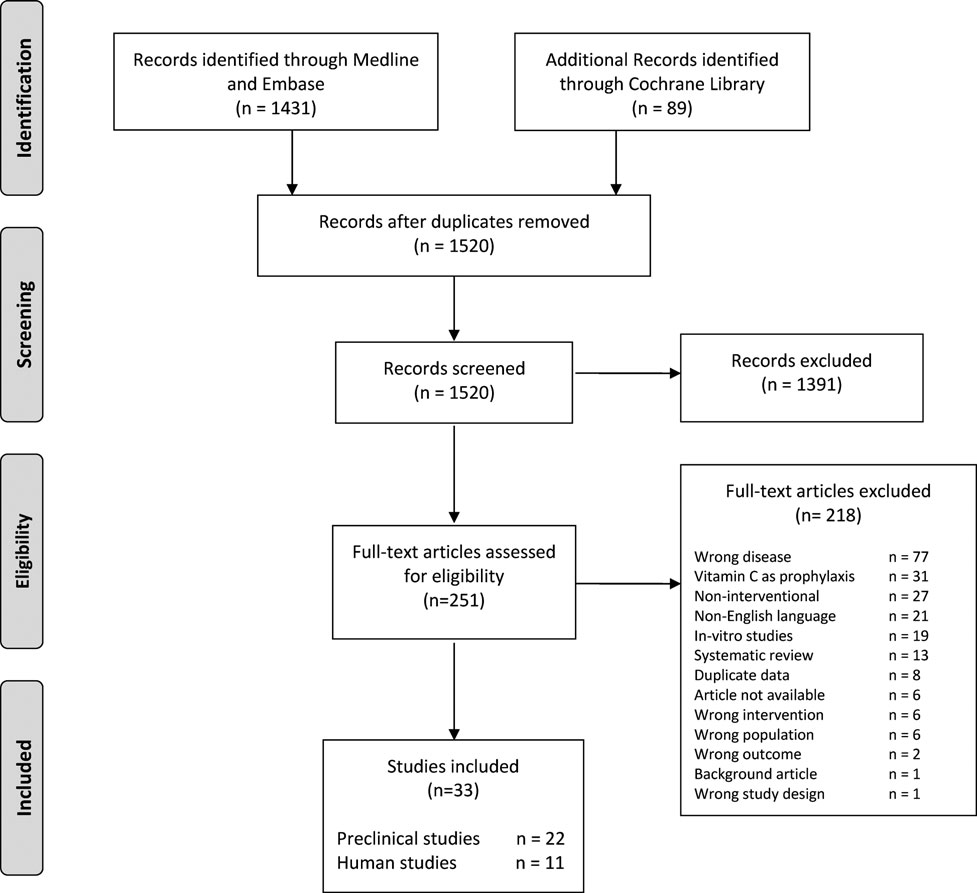

FIG. 1.

PRISMA ﬂow diagram.

2196

KANGISSER ET AL.

Table 1. Characteristics of Pre-Clinical Studies

Design

Design detail

Target condition

Sample size

Vitamin C regimen

Dose

Route

Duration

Results

Miura et al.,

200619

Placebo controlled

Vit C (variable dose) vs. placebo

Hypoxic brain injury

50 rats

0.04, 0.2, 1, or

5 mg/kg

IC

Once pre-insult

Y Neuronal cell death

Miura et al.,

200920

Placebo controlled

Vit C vs. placebo

Hypoxic brain injury

32 rats

750 mg/kg

IP

Once pre-insult

Y Neuronal cell death

Peeling et al.,

199821

Placebo controlled

Vit C + Vit E vs. placebo

ICH

16 rats

40 mg/kg BD

pre-ICH

60 mg/kg BD

post-ICH

PO

2/52 pre-insult

1/52 post-

insult

No difference in brain

edema or functional

outcome

Allahtavakoli

et al., 201522

Controlled study

No Tx vs. Vit C vs. r-tPA vs. Vit

C + r-tPA

Ischemic stroke

60 rats

500 mg/kg

PO

Once post-insult

Y Infarct size, improved

functional outcome

Bemeur et al.,

200523

Placebo controlled

Sham + hyperglycemia + DHA

vs.Ischemic + hyperglycemia

+ DHA vs. Ischemic +

hyperglycemia

Ischemic stroke

43 rats

50 mg/kg

IP

Once pre-insult

Y Brain edema during

hyperglycemia

Corbett et al.,

201524

Placebo controlled

Vit C + simvastatin vs.

ﬂuoxetine vs. Vit C +

simvastatin + ﬂuoxetine

Ischemic stroke

57 rats

20 mg/kg/d

PO

1/52 post-insult

Improved functional

outcome (Vit C +

simvastatin +

ﬂuoxetine)

De Sales et al.,

201925

Placebo controlled

Vit C vs. placebo vs. sham

Ischemic stroke

12 rats

750 mg/kg

IP

Once pre-insult

Improved functional

outcome

Ekici et al.,

200926

Controlled study

Sham vs. No Tx vs. DHA vs.

DHA + Vit D

Ischemic stroke

35 rats

250 mg/kg

IV

Once pre-insult

Y Lipid peroxidation

(DHA + Vit D)

Henry et al.,

199827

Placebo controlled

Vit C vs. placebo

Ischemic stroke

15 monkeys

500 mg/kg

IV

Once peri-insult

Y Infarct size

Sinha et al.,

200128

Placebo controlled

Sham vs. placebo vs. Vit C

liposomes vs. Vit E liposomes

vs. Vit C + E liposomes

vs.empty liposomes

Ischemic stroke

1089 rats

8 mg/kg

IV

Once pre-insult

Y Cerebral edema (Vit C

and combination

therapy)

Song et al.,

201529

Placebo controlled

DHA vs. placebo

Ischemic stroke

Not stated,

rats

100 mg/kg

IP

Once post-insult

Y BBB disruption, Y

brain edema

Huang et al.,

200130

Placebo controlled

Vit C vs. DHA vs. placebo

Ischemic stroke

111 mice

DHA: 40 mg/kg,

250 mg/kg

+500 mg/kg

Vit C:

250 mg/kg,

500 mg/kg

IV

Once post-insult

DHA: Y infarct size and

improved functional

outcomes

VC: no effect

Mack et al.,

200631

Placebo controlled

DHA vs. placebo

Ischemic stroke

57 mice

50 mg/kg,

100 mg/kg,

200 mg/kg

IV

Once post-insult

Y Infarct size, Y lipid

peroxidation

(continued)

2197

Table 1. (Continued)

Design

Design detail

Target condition

Sample size

Vitamin C regimen

Dose

Route

Duration

Results

Zamani et al.,

201332

Placebo controlled

Intact control vs. No Tx vs.

placebo vs.Vit C vs. A1

agonist vs. A1 antagonist vs.

Vit C + A1 agonist vs. Vit C +

A1 antagonist

Ischemic stroke

56 mice

100 mg/kg

IP

1/52 pre-insult

(Vit C only)

1/52 post-

insult (other)

Improved functional

outcome, Y neuronal

cell death

Zamani et al.,

201333

Controlled study

No Tx vs. sham vs. Vit C vs. A1

agonist vs. Vit C + A1 agonist

vs. Vit C + A1 antagonist

Vit C post-insult vs. Vit C

pre- + post-insult

Ischemic stroke

63 mice

100 mg/kg

IP

2/52 pre-insult

1/52 post-

insult

Improved functional

outcome, Y neuronal

cell death

Kameda et al.,

201234

Controlled study

Intact control vs. No Tx vs.

thrombin inhibitor vs. Vit C

vs. Vit C + thrombin inhibitor

SAH

Not stated,

rabbits

1.2 mg/kg

IC

Day 0 and day 2

post-insult

Improved vascular

reactivity (Vit C +

thrombin inhibitor)

Kawakami

et al., 199135

Controlled study

Oxy-Hb vs. Vit C–treated

Oxy-Hb

SAH

Not stated,

dogs

N/A

IC

Once

Y Vasoconstriction no.

Li et al., 201136

Controlled study

Intact control vs. No Tx vs. Vit C

vs. Insulin vs. Vit C + insulin

SAH

65 rabbits

40 mg/kg TDS

IM

5 days post-

insult

Y Vasospasm (Vit C +

insulin)

Ishaq et al.,

201337

Placebo controlled

Intact control vs. placebo vs. Vit

C vs. Vit E vs. Vit C + E

TBI

72 rats

45 mg/kg,

60 mg/kg

Unclear

2/52 pre- and

post-insult

[ Survival (synergistic

with Vit E)

Lin et al.,

201038

Placebo controlled

Intact control vs. placebo vs. Vit

C vs. Vit E vs. NOS inhibitor

vs. apocynin vs. allopurinol

TBI

72 rats

500 mg/kg daily

IP

Up to 3 months

Improved functional

outcome, Y BBB

disruption

Maekawa et al.,

202039

Controlled study

Stabilized Vit C pre- and

post-insult vs. Stabilized

Vit C post-insult vs. control

TBI

30 rats

250 mg/kg/d

PO

3 days pre- + 7

days post-

insult

7 days post-

insult

Improved functional

outcome (prophylactic

arm only)

Wang et al.,

201440

Placebo controlled

Sham vs. No Tx vs. Vit C vs.

statin vs. Vit C + statin

TBI

30 rats

20 mg/kg/d

PO

3 days post-

insult

Improved functional

outcome

BBB, blood–brain barrier; DHA, dehydroascorbic acid; IC, intracisternal; ICH, intracranial hemorrhage; IM, intramuscular; IP, intraperitoneal; IV, intravenous; N/A, not applicable; NOS, nitric oxide synthase; PO, per

oral; r-tPA, reverse tissue plasminogen activator; SAH, subarachnoid hemorrhage; TBI, traumatic brain injury; Tx, treatment; VC, vitamin C.

2198

Table 2. Characteristics of Clinical Studies

Design

Design details

Target

condition

Sample size

Vitamin C regimen

Dose

Route

Frequency

Duration

Results

Aly et al.,

200946

Randomized,

double-blind,

placebo-

controlled trial

Vit C + ibuprofen vs.

placebo

Neonatal HIE

60

100 mg/kg/d

IV

Daily

3 days

No difference in neurological

outcome

Garbagnati

et al., 200948

Randomized,

double-blind,

placebo-

controlled trial

Antioxidanta vs. fatty

acid vs. fatty acid,

antioxidanta vs.

placebo

Ischemic stroke

72

240 mg/d

PO

Daily

12 months

No effect in neurological or

functional outcome

Lagowska-

Lenard et al.,

201049

Controlled clinical

trial

Vit C vs. no

supplementation

Ischemic stroke

60

500 mg/d

IV

Daily

10 days

No effect on functional outcome

at 3 months

Polidori et al.,

200541

Randomized, open-

label clinical

trial

Vit C + aspirin vs.

aspirin only

Ischemic stroke

59

200 mg/d

PO

Daily

90 days

Y Lipid peroxidation

No difference in functional

outcome

Rabadi et al.,

200750

Retrospective case-

control study

Vit C vs. no

supplementation

Ischemic stroke

46

1000 mg/d

PO

Daily

Not reported

No difference in functional

outcome or disposition

Rabl et al.,

199644

Randomized,

placebo-

controlled study

Omnibiontac vs.

placebo

Carotid artery

surgery

57

1000 mg

IV

Once

Once

Y Markers of oxidative stress

and headache

Rumyantseva

et al., 201751

Randomized

controlled trial

Vit C vs. Cytoﬂavin

for 10/20 days

Ischemic stroke

373

1000 mg/d

IV

Daily

Not reported

Cytoﬂavin Y infarct size and

improved functional outcome

Ullegaddi et al.,

200542

Randomized

controlled trial

Vit C + Vit E vs. no

supplementation

Ischemic stroke

48

500 mg/d

PO

Daily

14 days

Y Markers of oxidative stress

and inﬂammation

Ullegaddi et al.,

200643

Randomized

controlled trial

Vit C + Vit E vs. Vit C

+ Vit E + Vit B

groupb vs. Vit B

groupb vs. no

supplementation

Ischemic stroke

92

500 mg/d

PO

Daily

14 days

Y Markers of oxidative stress

and inﬂammation

Kodama et al.,

200047

Observational

study

Vit C + urokinase

SAH

217

4 mg/mL at

30 mL/h

CI

Continuous

2–18 days

Vasospasm incidence 3%,

mortality 3%

Razmkon et al.,

201145

Randomized,

double-blind,

placebo-

controlled trial

Vit C (low dose) vs.

Vit C (high dose) vs.

Vit E vs. placebo

TBI

100

500 mg/d vs.

4–10 g/d

IV

Daily

7 days

High-dose Vit C Y perilesional

edema

aVit C (240 mg) + Vit E (290 mg) + polyphenols (150 mg) + b-carotene (19 mg) + n-3 polyunsaturated fatty acid (500 mg).

bVit B9 (5 mg) + Vit B2 (5 mg) + Vit 6 (50 mg) + Vit B12 (0.4 mg).

cMulti-vitamin: Vit B groups, C, and E.

CI, cisternal irrigation; HIE, hypoxic ischemic encephalopathy; IV, intravenous; PO, per oral; SAH, subarachnoid haemorrhage; TBI, traumatic brain injury.

2199

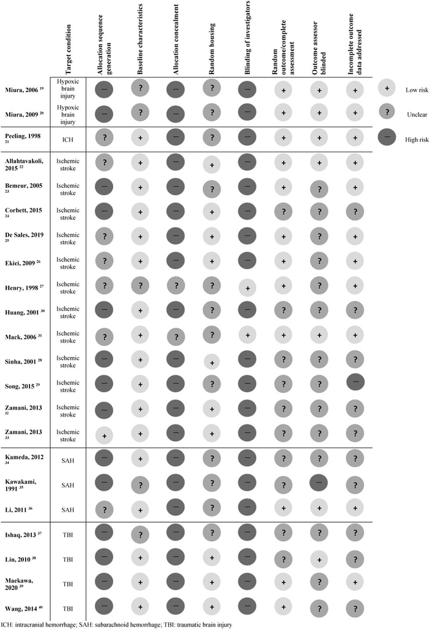

FIG. 2.

Risk of bias in pre-clinical studies. Risk of bias was assessed using the Systematic Review Center for Laboratory animal

Experimentation (SYRCLE) checklist.<sup>16</sup>

2200

Subarachnoid hemorrhage.

The only human data on ther-

apeutic vitamin C in subarachnoid hemorrhage comes from a

single-center (Fukushima, Japan) case series of 217 patients with

subarachnoid hemorrhage over a 14-year period from 1984 to

1998.<sup>47</sup>The authors describe their local practice of routine use of

cisternal irrigation therapy to prevent vasospasm after clipping of

ruptured aneurysms. The local technique involved an irrigation

catheter inserted into the Sylvian ﬁssure and a solution of Ringer’s

lactate with urokinase (120 IU/mL) and vitamin C (4 mg/mL) in-

fused at 30 mL/h for 2–18 days (mean, 9.9).<sup>47</sup>The contempora-

neous incidence of symptomatic vasospasm after subarachnoid

hemorrhage in the late 1980s was 32.5%, of which 34% developed

permanent neurological deﬁcits and 30% died.<sup>53</sup>The authors re-

ported a low rate of vasospasm (2.8%), with 1 patient (0.4%) de-

veloping a permanent neurological deﬁcit and no patients dying

from complications of vasospasm.<sup>47</sup>

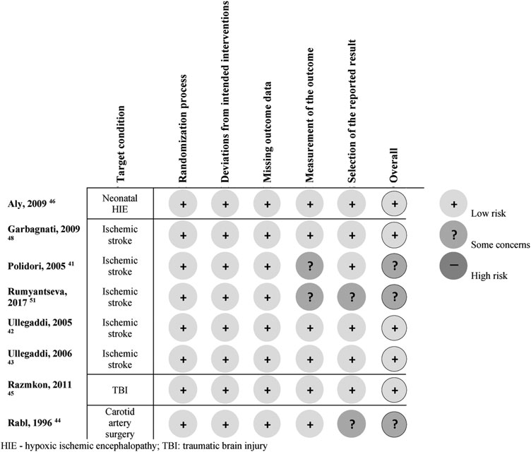

FIG. 3.

Risk of bias in human randomized controlled trials. Risk of bias in human randomized controlled trials was assessed using the

Cochrane risk-of-bias tool.<sup>17</sup>

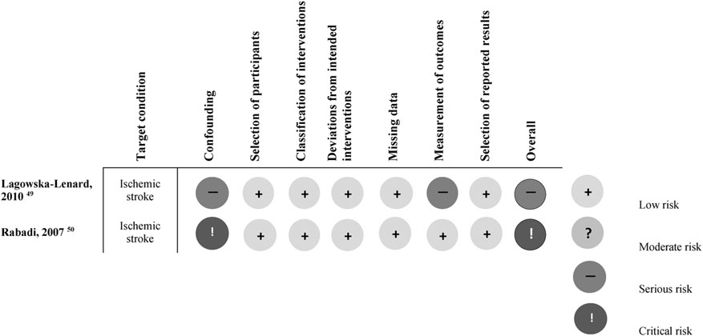

FIG. 4.

Risk of bias in human non-randomized trials. Risk of bias in human non-randomized trials was assessed using the ‘‘Risk Of

Bias In Non-randomized Studies – of Interventions (ROBINS-I)’’ tool.<sup>18</sup>

2201

Traumatic brain injury.

In the only trial of vitamin C in

traumatic brain injury, investigators randomized 100 patients with

severe traumatic brain injury to a 7-day regimen of ‘‘high-dose’’

intravenous vitamin C, low-dose vitamin C, vitamin E, or place-

bo.<sup>45</sup>High-dose intravenous vitamin C (maximum daily dose, 10 g)

decreased perilesional oedema on computed tomography (CT)

imaging, but this did not translate to an improvement in functional

outcome.<sup>45</sup>

Discussion

Key ﬁndings

We conducted a systematically structured scoping review to

evaluate whether vitamin C therapy has neuroprotective beneﬁt

after acute neurological insults. Using an assessment of method-

ology, we evaluated both animal model (pre-clinical) and human

studies of exogenous vitamin C in the setting of acute neurological

injury. We identiﬁed 22 relevant pre-clinical studies and 11 clinical

studies. We describe a pattern of promising observations using pre-

clinical studies of high-dose vitamin C (median dose, 120 mg/kg)

that have not translated to human trials utilizing substantially lesser

doses (median dose, *10 mg/kg).

The neutral results from human studies may represent a true

lack of efﬁcacy of vitamin C. However, it may also represent

inadequate dosing, particularly given the dosing regimens tested

vitamin C of £1000 mg/d, which would appear to be insufﬁcient to

achieve even physiological plasma concentrations during acute

illness. In a single-center observational study of 44 critically ill

patients, Carr and colleagues reported that 70% of patients had

hypovitaminosis C despite receiving recommended vitamin C

supplementation (mean daily intake, 125 – 88 mg/d).<sup>54</sup>In a study

of 57 elective post-operative patients in intensive care, up to 8 g of

intravenous vitamin C over 12 h was required to normalize plasma

vitamin C levels in the most severely deﬁcient patients.<sup>55</sup>In a

feasibility study of 24 patients, Fowler and collegaues reported

that 50 mg/kg/24 h restored plasma levels to normal within 6 h of

infusion commencement.<sup>56</sup>

Similarly, in a nested cohort study of 21 patients with septic

shock, nearly half of the study cohort had either vitamin C deﬁciency

or hypovitaminosis C at baseline, and 1.5g of intravenous vitamin C

every 6 h was required to maintain normal or supranormal vitamin C

levels.<sup>57</sup>Finally, in a study of vitamin C pharmacokinetics in the

critically ill, De Grooth and colleagues described that plasma vitamin

C levels could be restored to just above the lower normal threshold

with 2 g of intravenous vitamin C every 12 h (4g/d) and that this

regimen needs to be sustained for at least 48 h.<sup>58</sup>Based on these

pharmacokinetic data, the 11 human studies that evaluated potential

neuroprotective properties of vitamin C have used substantially

lesser doses of vitamin C than are required to reach physiological or

supraphysiological concentrations in other critically ill populations.

Five human trials in ischemic stroke utilized the oral route for vi-

tamin C delivery.<sup>41–43,48,50</sup>It is now recognized that bolus oral sup-

plementation is inadequate to achieve normal or supraphysiological

plasma levels of vitamin C in a critically ill population.<sup>59,60</sup>In health,

vitamin C absorption from the gut is determined by the saturable so-

dium vitamin C transport type 1 protein on the luminal surface of the

enterocyte, such that bioavailability reaches a ceiling effect above an

oraldose of *200mg.<sup>61</sup>This limited uptake is further compromised in

neurocritical illness where disturbances of intestinal function (ileus,

malabsorption, constipation, and diarrhea) occur frequently.<sup>62</sup>Ac-

cordingly, trials using the oral route were unlikely to have achieved

plasma concentrations to elicit any potential beneﬁt (or harm).

The only study utilizing intravenous vitamin C at a dose that is

known to achieve appropriate plasma concentrations in the criti-

cally ill was the randomized, blinded, placebo-controlled trial by

Razmkon and colleagues whereby 100 patients with severe trau-

matic brain injury were randomized to receive low-dose vitamin C,

high-dose vitamin C, vitamin E, or placebo.<sup>45</sup>Patients in the high-

dose arm were administered 10,000 mg of vitamin C intravenously

decreased perilesional edema on CT, but there was no statistically

signiﬁcant effect on patient-centered outcomes.

Five of the pre-clinical trials of ischemic stroke administered DHA,

the oxidized form of vitamin C.<sup>23,26,29–31</sup>Huang and colleagues

demonstrated the superiority of DHA compared to equipotent doses of

vitamin C enters the brain is incompletely understood; however, DHA

is thought to cross the blood barrier whereas the reduced form,

ascorbic acid, does not.<sup>63</sup>This unique permeability property offers

mechanistic plausibility that DHA may be superior to ascorbic acid in

acute neurological injury.<sup>30</sup>Given these animal data, the potential for

therapeutic use of DHA in human trials merits further investigation.

A ﬁnal key difference between the pre-clinical and clinical

studies is the timing of vitamin C delivery. In 13 of the pre-clinical

trials, vitamin C was administered before, or at the time of, the

neurological insult. Though not explicitly stated, by virtue of the

animal model study design, trials delivering vitamin C post-insult

would have had a shorter lag time to initiation of therapy than in

clinical trials where resuscitation and consent hamper early thera-

py.<sup>64</sup>Oxidative stress commences within minutes of an inciting

neurological insult and there is face validity that earlier initiation of

antioxidant treatment may be preferable.<sup>65</sup>

The single-center case series after subarachnoid hemorrhage re-

ported a low incidence of vasospasm and mortality when vitamin C

was infused into the subarachnoid space in patients who had un-

dergone clipping of ruptured intracranial aneurysms.<sup>47</sup>However,

because of the substantive issues with internal validity of these data,

it should not inﬂuence clinical practice. Interestingly, despite the

magnitude of effect reported by the investigators, the use of vitamin

C in this cohort has not been subjected to subsequent evaluation.

Implications

Our scoping review implies that there is a signal from pre-clinical

trials that vitamin C may be neuroprotective in acute neurological

injury and improve functional outcome. Moreover, it implies that

clinical trials to date have used dosing strategies, which, based on

current understanding of pharmacokinetics, would not achieve

physiological plasma concentrations in health, let alone pharmaco-

logical concentrations. The recent publication of four large, ran-

domized controlled trials of vitamin C in septic shock (ACTS,

ATESS, CITRUS-ALI, and VITAMINS) supports the rationale for

higher parenteral doses.<sup>66–69</sup>These trials compared intravenous vi-

tamin C, at doses ranging from 6 g/d up to 200 mg/kg/d, to placebo

for primary outcomes of time alive and free of vasopressor support<sup>66</sup>

and the change in Sequential Organ Failure Assessment score at 72 or

96h.<sup>67–69</sup>Recent experimental work in a sheep model of septic shock

suggests that much greater doses of vitamin C (4g/kg) has a more

pronounced physiological effect.<sup>70</sup>Taken together, these observa-

tions imply that prospective clinical trials of high-dose, early vitamin

C therapy after acute neurological insults are warranted.

2202

KANGISSER ET AL.

Strengths and limitations

To our knowledge, this is the ﬁrst systematic review of the neu-

roprotective properties of vitamin C therapy. Our review provides a

comprehensive assessment of the efﬁcacy of vitamin C as a neuro-

protective therapy in both pre-clinical in vivo studies and clinical trials.

Our review has some limitations. We conducted a scoping re-

view without formal meta-analysis. This was because we expected

considerable heterogeneity in the dosing regimens and outcome

measures across both pre-clinical and clinical trials. This concern

was conﬁrmed by our review. To increase the breadth of the review,

we included case series and observational studies acknowledging

that these yield a lower level of evidence and these studies had a

higher risk of bias. We assessed both pre-clinical and clinical

studies, and the lack of external validity in translating pre-clinical

research to the bedside is a well-recognized limitation of animal

models of neurological injury.<sup>71,72</sup>Rodents have vastly different

brain size and structure, higher function deﬁcits such as language

and emotion cannot be assessed, brain injury models represent

mild-moderate injury without prolonged periods of coma, and, as

outlined above, the time window for therapeutic intervention is

often hyperacute (or prophylactic).<sup>65,71</sup>Moreover, none of the pre-

other languages. However, there is no evidence of a systematic bias

when non-English articles are excluded.<sup>73</sup>

Conclusion

There is a dissociation in the efﬁcacy of vitamin C as a neuropro-

tective therapy between pre-clinical and clinical studies. The neutral

effect observed in human studies may be explained by a marked

difference in dosing regimens, whereby the median dose in animal

studies has been 10-fold greater than in human trials. Human studies

using pre-clinical doses of parenteral vitamin C appear desirable.

Funding Information

This research did not receive any speciﬁc grant from funding

agencies in the public, commercial, or not-for-proﬁt sectors.

Author Disclosure Statement

No competing ﬁnancial interests exist.

References

1. Hill, A., Wendt, S., Benstoem, C., Neubauer, C., Meybohm, P.,

Langlois, P., Adhikari, N.K., Heyland, D.K., and Stoppe, C. (2018).

Vitamin C to improve organ dysfunction in cardiac surgery patients-

review and pragmatic approach. Nutrients 10, 974.

2. Nualart, F., Mack, L., Garcia, A., Cisternas, P., Bongarzone, E.R.,

Heitzer, M., Jara, N., Martinez, F., Ferrada, L., Espinoza, F., Baeza,

V., and Salazar, K. (2014). Vitamin C transporters, recycling and the

bystander effect in the nervous system: SVCT2 versus Gluts. J. Stem

Cell Res. Ther. 4, 209.

3. Mandl, J., Szarka, A., and Banhegyi, G. (2009). Vitamin C: update on

physiology and pharmacology. Br. J. Pharmacol. 157, 1097–1110.

4. Harrison, F.E., and May, J.M. (2009). Vitamin C function in the brain:

vital role of the ascorbate transporter SVCT2. Free Radic. Biol. Med.

46, 719–730.

5. Rice, M.E., Lee, E.J., and Choy, Y. (1995). High levels of ascorbic acid,

not glutathione, in the CNS of anoxia-tolerant reptiles contrasted with

levels in anoxia-intolerant species. J. Neurochem. 64, 1790–1799.

6. Spoelstra-de Man, A.M., Elbers, P.W., and Oudemans-van Straaten,

H.M. (2018). Making sense of early high-dose intravenous vitamin C

in ischemia/reperfusion injury, in: Annual Update in Intensive Care

and Emergency Medicine 2018. J.L. Vincent (ed). Springer Interna-

tional, Cham, Switzerland, pps. 125–139.

7. Cherubini, A., Polidori, M.C., Bregnocchi, M., Pezzuto, S., Cecchetti, R.,

Ingegni, T., di Iorio, A., Senin, U., and Mecocci, P. (2000). Antioxidant

proﬁle and early outcome in stroke patients. Stroke 31, 2295–2300.

8. Polidori, M.C., Mecocci, P., and Frei, B. (2001). Plasma vitamin C

levels are decreased and correlated with brain damage in patients with

intracranial hemorrhage or head trauma. Stroke 32, 898–902.

9. Bayir, H., Kagan, V.E., Tyurina, Y.Y., Tyurin, V., Ruppel, R.A.,

Adelson, P.D., Graham, S.H., Janesko, K., Clark, R.S., and Kochanek,

P.M. (2002). Assessment of antioxidant reserves and oxidative stress

in cerebrospinal ﬂuid after severe traumatic brain injury in infants and

children. Pediatr. Res. 51, 571–578.

10. Polidori, M.C., Frei, B., Rordorf, G., Ogilvy, C.S., Koroshetz, W.J.,

and Beal, M.F. (1997). Increased levels of plasma cholesteryl ester

hydroperoxides in patients with subarachnoid hemorrhage. Free Radic.

Biol. Med. 23, 762–767.

11. Hanafy, K.A., and Selim, M.H. (2012). Antioxidant strategies in

neurocritical care. Neurotherapeutics 9, 44–55.

12. Spoelstra-de Man, A.M.E., Elbers, P.W.G., and Oudemans-van

Straaten, H.M. (2018). Making sense of early high-dose intravenous

vitamin C in ischemia/reperfusion injury. Crit. Care 22, 70.

13. Nauman, G., Gray, J.C., Parkinson, R., Levine, M., and Paller, C.J.

(2018). Systematic review of intravenous ascorbate in cancer clinical

trials. Antioxidants (Basel) 7, 89.

14. Putzu, A., Daems, A.M., Lopez-Delgado, J.C., Giordano, V.F., and

Landoni, G. (2019). The effect of vitamin C on clinical outcome in

critically ill patients: a systematic review with meta-analysis of ran-

domized controlled trials. Crit. Care Med. 47, 774–783.

15. Tricco,A.C.,Lillie,E.,Zarin,W.,O’Brien,K.K.,Colquhoun,H.,Levac,D.,

Moher, D., Peters, M.D.J., Horsley, T., Weeks, L., Hempel, S., Akl, E.A.,

Chang, C., McGowan, J., Stewart, L., Hartling, L., Aldcroft, A., Wilson,

M.G., Garritty, C., Lewin, S., Godfrey, C.M., Macdonald, M.T., Langlois,

E.V., Soares-Weiser, K., Moriarty, J., Clifford, T., Tuncalp, O., and Straus,

S.E. (2018). PRISMA Extension for Scoping Reviews (PRISMA-ScR):

checklist and explanation. Ann. Intern. Med. 169, 467–473.

16. Hooijmans, C.R., Rovers, M.M., de Vries, R.B., Leenaars, M.,

Ritskes-Hoitinga, M., and Langendam, M.W. (2014). SYRCLE’s risk

of bias tool for animal studies. BMC Med. Res. Methodol. 14, 43.

17. Sterne, J.A.C., Savovic, J., Page, M.J., Elbers, R.G., Blencowe, N.S.,

Boutron, I., Cates, C.J., Cheng, H.Y., Corbett, M.S., Eldridge, S.M.,

Emberson, J.R., Hernan, M.A., Hopewell, S., Hrobjartsson, A., Jun-

queira, D.R., Juni, P., Kirkham, J.J., Lasserson, T., Li, T., McAleenan,

A., Reeves, B.C., Shepperd, S., Shrier, I., Stewart, L.A., Tilling, K.,

White, I.R., Whiting, P.F., and Higgins, J.P.T. (2019). RoB 2: a revised

tool for assessing risk of bias in randomised trials. BMJ 366, l4898.

18. Sterne, J.A., Hernan, M.A., Reeves, B.C., Savovic, J., Berkman, N.D.,

Viswanathan, M., Henry, D., Altman, D.G., Ansari, M.T., Boutron, I.,

Carpenter, J.R., Chan, A.W., Churchill, R., Deeks, J.J., Hrobjartsson,

A., Kirkham, J., Juni, P., Loke, Y.K., Pigott, T.D., Ramsay, C.R.,

Regidor, D., Rothstein, H.R., Sandhu, L., Santaguida, P.L., Schune-

mann, H.J., Shea, B., Shrier, I., Tugwell, P., Turner, L., Valentine,

J.C., Waddington, H., Waters, E., Wells, G.A., Whiting, P.F., and

Higgins, J.P. (2016). ROBINS-I: a tool for assessing risk of bias in

non-randomised studies of interventions. BMJ 355, i4919.

19. Miura, S., Ishida, A., Nakajima, W., Ohmura, A., Kawamura, M., and

Takada, G. (2006). Intraventricular ascorbic acid administration de-

creases hypoxic-ischemic brain injury in newborn rats. Brain Res.

1095, 159–166.

20. Miura, S., Ishida-Nakajima, W., Ishida, A., Kawamura, M., Ohmura, A.,

Oguma, R., Sato, Y., and Takahashi, T. (2009). Ascorbic acid protects

the newborn rat brain from hypoxic-ischemia. Brain Dev. 31, 307–317.

21. Peeling, J., Yan, H.J., Chen, S.G., Campbell, M., and Del Bigio, M.R.

(1998). Protective effects of free radical inhibitors in intracerebral

hemorrhage in rat. Brain Res. 795, 63–70.

22. Allahtavakoli, M., Amin, F., Esmaeeli-Nadimi, A., Shamsizadeh, A.,

Kazemi-Arababadi, M., and Kennedy, D. (2015). Ascorbic acid re-

duces the adverse effects of delayed administration of tissue plas-

minogen activator in a rat stroke model. Basic Clin. Pharmacol.

Toxicol. 117, 335–339.

23. Bemeur, C., Ste-Marie, L., Desjardins, P., Vachon, L., Butterworth,

R.F., Hazell, A.S., and Montgomery, J. (2005). Dehydroascorbic acid

normalizes several markers of oxidative stress and inﬂammation in

acute hyperglycemic focal cerebral ischemia in the rat. Neurochem.

Int. 46, 399–407.

NEUROPROTECTIVE PROPERTIES OF VITAMIN C

2203

24. Corbett, A.M., Sieber, S., Wyatt, N., Lizzi, J., Flannery, T., Sibbit, B.,

and Sanghvi, S. (2015). Increasing neurogenesis with ﬂuoxetine,

simvastatin and ascorbic acid leads to functional recovery in ischemic

stroke. Recent Pat. Drug Deliv. Formul. 9, 158–166.

25. De Sales, K.P.F., Pinto, B.A.S., Ribeiro, N.L.X., Melo, T.M., Galvao-

Moreira, L.V., De Brito Filho, S.B., and Nigri, F. (2019). Effects of

vitamin C on the prevention of ischemia-reperfusion brain injury:

experimental study in rats. Int. J. Vasc. Med. 2019, 4090549.

26. Ekici, F., Ozyurt, B., and Erdogan, H. (2009). The combination of

vitamin D<inf>3</inf> and dehydroascorbic acid administration at-

tenuates brain damage in focal ischemia. Neurol. Sci. 30, 207–212.

27. Henry, P.T., and Chandy, M.J. (1998). Effect of ascorbic acid on

infarct size in experimental focal cerebral ischaemia and reperfusion

in a primate model. Acta Neurochir. 140, 977–980.

28. Sinha, J., Das, N., and Basu, M.K. (2001). Liposomal antioxidants in

combating ischemia-reperfusion injury in rat brain. Biomed. Phar-

macother. 55, 264–271.

29. Song, J., Park, J., Kim, J.H., Choi, J.Y., Kim, J.Y., Lee, K.M., and

Lee, J.E. (2015). Dehydroascorbic acid attenuates ischemic brain

edema and neurotoxicity in cerebral ischemia: an in vivo study. Exp.

Neurobiol. 24, 41–54.

30. Huang, J., Agus, D.B., Winfree, C.J., Kiss, S., Mack, W.J., McTag-

gart, R.A., Choudhri, T.F., Kim, L.J., Mocco, J., Pinsky, D.J., Fox,

W.D., Israel, R.J., Boyd, T.A., Golde, D.W., and Connolly, E.S., Jr.

(2001). Dehydroascorbic acid, a blood-brain barrier transportable form

of vitamin C, mediates potent cerebroprotection in experimental

stroke. Proc. Natl. Acad. Sci. U. S. A. 98, 11720–11724.

31. Mack, W.J., Mocco, J., Ducruet, A.F., Laufer, I., King, R.G., Zhang,

Y.,

Guo,

W.,

Pinsky,

D.J.

and

Connolly,

E.S.,

Jr.

(2006).

A cerebroprotective dose of intravenous citrate/sorbitol-stabilized

dehydroascorbic acid is correlated with increased cerebral ascorbic

acid and inhibited lipid peroxidation after murine reperfused stroke.

Neurosurgery 59, 383–388; discussion, 383–388.

32. Zamani, M., Katebi, M., Mehdizadeh, M., Kafami, L., Malek, F., and

Soleimani, M. (2013). Combination therapy with a1 receptor agonist

and vitamin c improved working memory in a mouse model of global

ischemia-reperfusion. Basic Clin. Neurosci. 4, 5–10.

33. Zamani, M., Soleimani, M., Golab, F., Mohamadzadeh, F., Mehdi-

zadeh, M., and Katebi, M. (2013). NeuroProtective effects of adeno-

sine receptor agonist coadministration with ascorbic acid on CA1

hippocampus in a mouse model of ischemia reperfusion injury. Metab.

Brain Dis. 28, 367–374.

34. Kameda, K., Kikkawa, Y., Hirano, M., Matsuo, S., Sasaki, T., and

Hirano, K. (2012). Combined argatroban and anti-oxidative agents

prevents increased vascular contractility to thrombin and other ligands

after subarachnoid haemorrhage. Br. J. Pharmacol. 165, 106–119.

35. Kawakami, M., Kodama, N., and Toda, N. (1991). Suppression of the

cerebral vasospastic actions of oxyhemoglobin by ascorbic acid.

Neurosurgery 28, 33–40.

36. Li, S., Xue, J., Shi, J., Yin, H., and Zhang, Z. (2011). Combinatorial

administration of insulin and vitamin C alleviates the cerebral vaso-

spasm after experimental subarachnoid hemorrhage in rabbit. BMC

Neurosci. 12, 77.

37. Ishaq, G.M., Saidu, Y., Bilbis, L.S., Muhammad, S.A., Jinjir, N., and

Shehu, B.B. (2013). Effects of alpha-tocopherol and ascorbic acid in

the severity and management of traumatic brain injury in albino rats. J.

Neurosci. Rural Pract. 4, 292–297.

38. Lin, J.L., Huang, Y.H., Shen, Y.C., Huang, H.C.,, and Liu, P.H.

(2010). Ascorbic acid prevents blood-brain barrier disruption and

sensory deﬁcit caused by sustained compression of primary somato-

sensory cortex. J. Cereb. Blood Flow Metab. 30, 1121–1136.

39. Maekawa, T., Uchida, T., Nakata-Horiuchi, Y., Kobayashi, H., Ka-

wauchi, S., Kinoshita, M., Saitoh, D., and Sato, S. (2020). Oral

ascorbic acid 2-glucoside prevents coordination disorder induced via

laser-induced shock waves in rat brain. PLoS One 15, e0230774.

40. Wang, K.W., Wang, H.K., Chen, H.J., Liliang, P.C., Liang, C.L., Tsai,

Y.D., Cho, C.L., and Lu, K. (2014). Simvastatin combined with anti-

oxidant attenuates the cerebral vascular endothelial inﬂammatory re-

sponse in a rat traumatic brain injury. Biomed Res. Int. 2014, 910260.

41. Polidori, M.C., Pratico, D., Ingegni, T., Mariani, E., Spazzafumo, L.,

Sindaco, P.D., Cecchetti, R., Yao, Y., Ricci, S., Cherubini, A., Stahl,

W., Sies, H., Senin, U., and Mecocci, P. (2005). Effects of vitamin C

and aspirin in ischemic stroke-related lipid peroxidation: results of the

AVASAS (Aspirin Versus Ascorbic acid plus Aspirin in Stroke)

Study. BioFactors 24, 265–274.

42. Ullegaddi, R., Powers, H.J., and Gariballa, S.E. (2005). Antioxidant

supplementation enhances antioxidant capacity and mitigates oxida-

tive damage following acute ischaemic stroke. Eur. J. Clin. Nutr. 59,

1367–1373.

43. Ullegaddi, R., Powers, H.J., and Gariballa, S.E. (2006). Antioxidant

supplementation with or without B-group vitamins after acute ische-

mic stroke: a randomized controlled trial. J. Parenter. Enteral Nutr. 30,

108–114.

44. Rabl, H., Khoschsorur, G., Hauser, H., Petek, W., and Esterbauer, H.

(1996). Diminished production of malondialdehyde after carotid artery

surgery as a result of vitamin administration. Med. Sci. Res. 24, 777–780.

45. Razmkon, A., Sadidi, A., Sherafat-Kazemzadeh, E., Mehrafshan, A.,

Jamali, M., Malekpour, B., and Saghaﬁnia, M. (2011). Administration

of vitamin C and vitamin E in severe head injury: a randomized

double-blind controlled trial. Clin. Neurosurg. 58, 133–137.

46. Aly, H., Abd-Rabboh, L., El-Dib, M., Nawwar, F., Hassan, H., Aaref,

M., Abdelrahman, S., and Elsayed, A. (2009). Ascorbic acid combined

with ibuprofen in hypoxic ischemic encephalopathy: a randomized

controlled trial. J. Perinatol. 29, 438–443.

47. Kodama, N., Sasaki, T., Kawakami, M., Sato, M., and Asari, J. (2000).

Cisternal irrigation therapy with urokinase and ascorbic acid for pre-

vention of vasospasm after aneurysmal subarachnoid hemorrhage.

Outcome in 217 patients. Surg. Neurol. 53, 110–118.

48. Garbagnati, F., Cairella, G., De Martino, A., Multari, M., Scognamiglio,

U., Venturiero, V., and Paolucci, S. (2009). Is antioxidant and n-3

supplementation able to improve functional status in poststroke patients?

Results from the nutristroke trial. Cerebrovasc. Dis. 27, 375–383.

49. Lagowska-Lenard, M., Stelmasiak, Z., and Bartosik-Psujek, H. (2010).

Inﬂuence of vitamin C on markers of oxidative stress in the earliest

period of ischemic stroke. Pharmacol. Rep. 62, 751–756.

50. Rabadi, M.H., and Kristal, B.S. (2007). Effect of vitamin C supple-

mentation on stroke recovery: a case-control study. Clin. Interv. Aging

2, 147–151.

51. Rumyantseva, S.A., Kovalenko, A.L., Silina, E.V., Stupin, V.A.,

Kabaeva, E.N., Chichanovskaya, L.V., Nazarov, M.V., Tsukurova,

L.A., Burenichev, D.V., Golikov, K.V., Sal’nikov, M.V., Belova,

L.A., Mashin, V.V., Mazina, N.K., Zhilina, E.A., Kolotik-Kameneva,

O.Y., and Sherman, M.A. (2017). Efﬁcacy of complex antioxidant

energy correction of different durations in the treatment of cerebral

infarction (results of a multicenter randomized study). Neurosci. Be-

hav. Physiol. 47, 288–295.

52. Kodama, N., Sasaki, T., Matsumoto, M., Suzuki, K., Sakuma, J.,

Endo, Y., Oinuma, M., Ishikawa, T., and Sato, T. (2008). Prevention

of symptomatic vasospasm—effect of continuous cisternal irrigation

with urokinase and ascorbic acid, in: Cerebral Vasospasm: New

Strategies in Research and Treatment. T. Kırısx and J.H. Zhang (eds).

Springer-Verlag: Vienna, Austria, pps. 325–327.

53. Dorsch, N.W., and King, M.T. (1994). A review of cerebral vaso-

spasm in aneurysmal subarachnoid haemorrhage part I: incidence and

effects. J. Clin. Neurosci. 1, 19–26.

54. Carr, A.C., Rosengrave, P.C., Bayer, S., Chambers, S., Mehrtens, J.,

and Shaw, G.M. (2017). Hypovitaminosis C and vitamin C deﬁciency

in critically ill patients despite recommended enteral and parenteral

intakes. Crit. Care 21, 300.

55. Rumelin, A., Jaehde, U., Kerz, T., Roth, W., Kramer, M., and Fauth,

U. (2005). Early postoperative substitution procedure of the antioxi-

dant ascorbic acid. J. Nutr. Biochem. 16, 104–108.

56. Fowler, A.A., 3rd, Syed, A.A., Knowlson, S., Sculthorpe, R., Farthing,

D., DeWilde, C., Farthing, C.A., Larus, T.L., Martin, E., Brophy, D.F.,

Gupta, S., Medical Respiratory Intensive Care Unit, N., Fisher, B.J.,

and Natarajan, R. (2014). Phase I safety trial of intravenous ascorbic

acid in patients with severe sepsis. J. Transl. Med. 12, 32.

57. Hudson, E.P., Collie, J.T., Fujii, T., Luethi, N., Udy, A.A., Doherty, S.,

Eastwood, G., Yanase, F., Naorungroj, T., Bitker, L., Abdelhamid, Y.A.,

Greaves, R.F., Deane, A.M., and Bellomo, R. (2019). Pharmacokinetic

data support 6-hourly dosing of intravenous vitamin C to critically ill

patients with septic shock. Crit. Care Resusc. 21, 236–242.

58. de Grooth, H.J., Manubulu-Choo, W.P., Zandvliet, A.S., Spoelstra-de

Man, A.M.E., Girbes, A.R., Swart, E.L., and Oudemans-van Straaten,

H.M. (2018). Vitamin C pharmacokinetics in critically ill patients: a

randomized trial of four IV regimens. Chest 153, 1368–1377.

59. McNamara, R., Deane, A.M., Anstey, J., and Bellomo, R. (2018).

Understanding the rationale for parenteral ascorbate (vitamin C)

during an acute inﬂammatory reaction: a biochemical perspective.

Crit. Care Resusc. 20, 174–179.

2204

KANGISSER ET AL.

60. Duconge, J., Miranda-Massari, J.R., Gonzalez, M.J., Jackson, J.A.,

Warnock, W., and Riordan, N.H. (2008). Pharmacokinetics of vitamin

C: insights into the oral and intravenous administration of ascorbate.

P. R. Health Sci. J 27, 7–19.

61. Blanchard, J., Tozer, T.N., and Rowland, M. (1997). Pharmacokinetic

perspectives on megadoses of ascorbic acid. Am. J. Clin. Nutr. 66,

1165–1171.

62. Wernerman, J., Christopher, K.B., Annane, D., Casaer, M.P., Coop-

ersmith, C.M., Deane, A.M., De Waele, E., Elke, G., Ichai, C., Kar-

vellas,

C.J.,

McClave,

S.A.,

Oudemans-van

Straaten,

H.M.,

Rooyackers, O., Stapleton, R.D., Takala, J., van Zanten, A.R.H.,

Wischmeyer, P.E., Preiser, J.C., and Vincent, J.L. (2019). Metabolic

support in the critically ill: a consensus of 19. Crit. Care 23, 318.

63. Agus, D.B., Gambhir, S.S., Pardridge, W.M., Spielholz, C., Baselga,

J., Vera, J.C., and Golde, D.W. (1997). Vitamin C crosses the blood-

brain barrier in the oxidized form through the glucose transporters. J.

Clin. Invest. 100, 2842–2848.

64. Menon, D.K. (2009). Unique challenges in clinical trials in traumatic

brain injury. Crit. Care Med. 37, 1 Suppl., S129–S135.

65. Leichtle, S.W., Sarma, A.K., Strein, M., Yajnik, V., Rivet, D., Sima, A.,

and Brophy, G.M. (2020). High-dose intravenous ascorbic acid: ready

for prime time in traumatic brain injury? Neurocrit. Care 32, 333–339.

66. Fujii, T., Luethi, N., Young, P.J., Frei, D.R., Eastwood, G.M., French,

C.J., Deane, A.M., Shehabi, Y., Hajjar, L.A., Oliveira, G., Udy, A.A.,

Orford, N., Edney, S.J., Hunt, A.L., Judd, H.L., Bitker, L., Cioccari, L.,

Naorungroj, T., Yanase, F., Bates, S., McGain, F., Hudson, E.P., Al-

Bassam, W., Dwivedi, D.B., Peppin, C., McCracken, P., Orosz, J.,

Bailey, M., Bellomo, R., and Investigators, V.T. (2020). Effect of vi-

tamin C, hydrocortisone, and thiamine vs hydrocortisone alone on time

alive and free of vasopressor support among patients with septic shock:

the VITAMINS Randomized Clinical Trial. JAMA 323, 423–431.

67. Moskowitz, A., Huang, D.T., Hou, P.C., Gong, J., Doshi, P.B., Gros-

sestreuer, A.V., Andersen, L.W., Ngo, L., Sherwin, R.L., Berg, K.M.,

Chase, M., Cocchi, M.N., McCannon, J.B., Hershey, M., Hilewitz, A.,

Korotun, M., Becker, L.B., Otero, R.M., Uduman, J., Sen, A., and

Donnino, M.W.; ACTS Clinical Trial Investigators. (2020). Effect of

ascorbic acid, corticosteroids, and thiamine on organ injury in septic

shock: the ACTS Randomized Clinical Trial. JAMA 324, 642–650.

68. Hwang, S.Y., Ryoo, S.M., Park, J.E., Jo, Y.H., Jang, D.H., Suh, G.J.,

Kim, T., Kim, Y.J., Kim, S., Cho, H., Jo, I.J., Chung, S.P., Choi, S.H.,

Shin, T.G., Kim, W.Y., and Korean Shock Society (KoSS). (2020).

Combination therapy of vitamin C and thiamine for septic shock: a

multi-centre, double-blinded randomized, controlled study. Intensive

Care Med. doi: 10.1007/s00134-020-06191-3.

69. Fowler, A.A. III, Truwit, J.D., Hite, R.D., Morris, P.E., DeWilde, C.,

Priday, A., Fisher, B., Thacker, L.R. II, Natarajan, R., Brophy, D.F.,

Sculthorpe, R., Nanchal, R., Syed, A., Sturgill, J., Martin, G.S., Sev-

ransky, J., Kashiouris, M., Hamman, S., Egan, K.F., Hastings, A.,

Spencer, W., Tench, S., Mehkri, O., Bindas, J., Duggal, A., Graf, J.,

Zellner, S., Yanny, L., McPolin, C., Hollrith, T., Kramer, D., Ojielo,

C., Damm, T., Cassity, E., Wieliczko, A., and Halquist, M. (2019).

Effect of vitamin C infusion on organ failure and biomarkers of in-

ﬂammation and vascular injury in patients with sepsis and severe acute

respiratory failure: the CITRIS-ALI Randomized Clinical Trial.

JAMA 322, 1261–1270.

70. Lankadeva, Y.R., Peiris, R.M., Okazaki, N., Birchall, I.E., Trask-

Marino, A., Dornom, A., Vale, T.A.M., Evans, R.G., Yanase, F.,

Bellomo, R., and May, C.N. (2021). Reversal of the pathophysiolog-

ical responses to Gram-negative sepsis by megadose vitamin C. Crit.

Care Med. 49, e179–e190.

71. Marklund, N., and Hillered, L. (2011). Animal modelling of traumatic

brain injury in preclinical drug development: where do we go from

here? Br. J. Pharmacol. 164, 1207–1229.

72. Pound, P. and Ritskes-Hoitinga, M. (2018). Is it possible to overcome

issues of external validity in preclinical animal research? Why most

animal models are bound to fail. J. Transl. Med. 16, 304.

73. Morrison, A., Polisena, J., Husereau, D., Moulton, K., Clark, M.,

Fiander, M., Mierzwinski-Urban, M., Clifford, T., Hutton, B., and

Rabb, D. (2012). The effect of English-language restriction on sys-

tematic review-based meta-analyses: a systematic review of empirical

studies. Int. J. Technol. Assess. Health Care 28, 138–144.

Address correspondence to:

Mark P. Plummer, PhD

Department of Intensive Care

Royal Melbourne Hospital

300 Grattan Street

Parkville, Victoria 3050

Australia

E-mail: mark.plummer@mh.org.au

NEUROPROTECTIVE PROPERTIES OF VITAMIN C

2205